Decision Tree Analysis Group 7 2025-12-13

# DECISION TREES ANALYSIS – CLASSIFICATION

## Dataset Description.

The **Diabetis** dataset contains information collected on health metrics and diagnostic measurements used to predict the onset of diabetis. It coontains medical data from individual and indicates if they have diabetes or not.

### Variables Used:

| Variable | Description |
| --- | --- |
| `Pregnancies` | Number of times individual is pregant |
| `Glocose` | Plasma glucose concentration froma 2-hour glucose tolerance test |
| `BloodPressure` | Diastolic blood pressure (mm Hg) |
| `Skin thickness` | Triceps skin thickness |
| `Insulin` | 2 hour serum insulin (mu U/ml) |
| `BMI` | Body Mass Index (weight in kg / height in m2) |
| `DiabetesPedigreeFunction` | A function that scores the likelihood of diabetis based on family history |
| `Age` | Age of the individual in years |
| `Outcome` | Target variable indicating diabetes diagnosis |

## Libraries and Setup

Key R libraries tools are loaded to streamline data processing, modeling, and evaluation.

```r
# Load necessary libraries
library(MASS)        # For Boston dataset
library(rpart)       # For decision tree modeling
library(rpart.plot)  # For tree visualization
library(caret)       # For train-test split and evaluation
library(e1071)       # For model tuning
library(tidyverse)
library(kableExtra)
library(ggthemes)    # For advanced ggplot themes
library(scales)      # For scale formatting
library(forcats)# For categorical variable handling
#library(modeldata)
#library(tidymodels)
```

##Loading the Data

```r
diabetis = read_csv("Diabete_data_1.csv")
diabetis$Insulin <- NULL
diabetis
```

```
## # A tibble: 768 × 8
##    Pregnancies Glucose Blood_Pressure Skin_Thickness   BMI
##          <dbl>   <dbl>          <dbl>          <dbl> <dbl>
##  1           6     148             72             35  33.6
##  2           1      85             66             29  26.6
##  3           8     183             64             NA  23.3
##  4           1      89             66             23  28.1
##  5           0     137             40             35  43.1
##  6           5     116             74             NA  25.6
##  7           3      78             50             32  31
##  8          10     115             NA             NA  35.3
##  9           2     197             70             45  30.5
## 10           8     125             96             NA  NA
## # ℹ 758 more rows
## # ℹ 3 more variables: Diabetes_Pedigree_Function <dbl>, Age <dbl>,
## #   Outcome <dbl>
```

## Data Inspection

```r
str(diabetis)
```

```
## spc_tbl_ [768 × 8] (S3: spec_tbl_df/tbl_df/tbl/data.frame)
##  $ Pregnancies               : num [1:768] 6 1 8 1 0 5 3 10 2 8 ...
##  $ Glucose                   : num [1:768] 148 85 183 89 137 116 78 115 197 125 ...
##  $ Blood_Pressure            : num [1:768] 72 66 64 66 40 74 50 NA 70 96 ...
##  $ Skin_Thickness            : num [1:768] 35 29 NA 23 35 NA 32 NA 45 NA ...
##  $ BMI                       : num [1:768] 33.6 26.6 23.3 28.1 43.1 25.6 31 35.3 30.5 NA ...
##  $ Diabetes_Pedigree_Function: num [1:768] 0.627 0.351 0.672 0.167 2.288 ...
##  $ Age                       : num [1:768] 50 31 32 21 33 30 26 29 53 54 ...
##  $ Outcome                   : num [1:768] 1 0 1 0 1 0 1 0 1 1 ...
##  - attr(*, "spec")=
##   .. cols(
##   ..   Pregnancies = col_double(),
##   ..   Glucose = col_double(),
##   ..   Blood_Pressure = col_double(),
##   ..   Skin_Thickness = col_double(),
##   ..   Insulin = col_double(),
##   ..   BMI = col_double(),
##   ..   Diabetes_Pedigree_Function = col_double(),
##   ..   Age = col_double(),
##   ..   Outcome = col_double()
##   .. )
##  - attr(*, "problems")=<externalptr>
```

```r
summary(diabetis)
```

```
##   Pregnancies        Glucose      Blood_Pressure   Skin_Thickness
##  Min.   : 0.000   Min.   : 44.0   Min.   : 24.00   Min.   : 7.00
##  1st Qu.: 1.000   1st Qu.: 99.0   1st Qu.: 64.00   1st Qu.:22.00
##  Median : 3.000   Median :117.0   Median : 72.00   Median :29.00
##  Mean   : 3.845   Mean   :121.7   Mean   : 72.41   Mean   :29.15
##  3rd Qu.: 6.000   3rd Qu.:141.0   3rd Qu.: 80.00   3rd Qu.:36.00
##  Max.   :17.000   Max.   :199.0   Max.   :122.00   Max.   :99.00
##                   NA's   :5       NA's   :35       NA's   :227
##       BMI        Diabetes_Pedigree_Function      Age           Outcome
##  Min.   :18.20   Min.   :0.0780             Min.   :21.00   Min.   :0.000
##  1st Qu.:27.50   1st Qu.:0.2437             1st Qu.:24.00   1st Qu.:0.000
##  Median :32.30   Median :0.3725             Median :29.00   Median :0.000
##  Mean   :32.46   Mean   :0.4719             Mean   :33.24   Mean   :0.349
##  3rd Qu.:36.60   3rd Qu.:0.6262             3rd Qu.:41.00   3rd Qu.:1.000
##  Max.   :67.10   Max.   :2.4200             Max.   :81.00   Max.   :1.000
##  NA's   :11
```

## DATA CLEANING

```r
# Check for missing values
sum(is.na(diabetis))
```

```
## [1] 278
```

```r
# Removin NA in the Dataset
attach(diabetis)
diabetis_cln <- diabetis %>% drop_na(Pregnancies,
                                     Glucose,
                                     Blood_Pressure,
                                     Skin_Thickness,
                                     BMI,
                                     Age,
                                     Outcome)

diabetis_cln
```

```
## # A tibble: 532 × 8
##    Pregnancies Glucose Blood_Pressure Skin_Thickness   BMI
##          <dbl>   <dbl>          <dbl>          <dbl> <dbl>
##  1           6     148             72             35  33.6
##  2           1      85             66             29  26.6
##  3           1      89             66             23  28.1
##  4           0     137             40             35  43.1
##  5           3      78             50             32  31
##  6           2     197             70             45  30.5
##  7           1     189             60             23  30.1
##  8           5     166             72             19  25.8
##  9           0     118             84             47  45.8
## 10           1     103             30             38  43.3
## # ℹ 522 more rows
## # ℹ 3 more variables: Diabetes_Pedigree_Function <dbl>, Age <dbl>,
## #   Outcome <dbl>
```

```r
sum(is.na(diabetis_cln))
```

```
## [1] 0
```

No NA values in this dataset, so no imputation needed. This step is essential to avoid biases or errors during modeling.

## Histograms

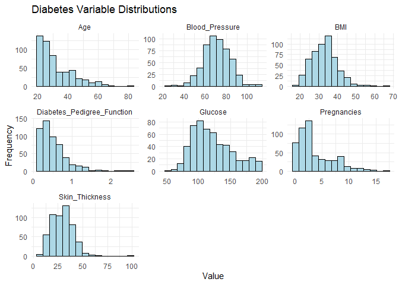

```r
# Only numeric continuous variables (exclude Outcome)
diabetis_cln <- diabetis %>% drop_na()

numeric_vars <- diabetis_cln %>%
  select(Pregnancies,
         Glucose,
         Blood_Pressure,
         Skin_Thickness,
         BMI,
         Diabetes_Pedigree_Function,
         Age) %>%
  mutate(across(everything(), ~as.numeric(as.character(.)))) %>%
  drop_na() # We used mutate() to convert all continuous variables into numeric format so that ggplot can create histograms without errors.

# Reshape the data (pivot_longer instead of gather)

long_data <- numeric_vars %>%
  pivot_longer(cols = everything(),
               names_to = "variable",
               values_to = "value")


# Create histograms
ggplot(long_data, aes(x = value)) +
  geom_histogram(fill = "lightblue", color = "black", bins = 15) +
  facet_wrap(~variable, scales = "free") +
  labs(title = "Diabetes Variable Distributions",
       x = "Value",
       y = "Frequency") +
  theme_minimal()
```

### Explanation

The histograms of the diabetes dataset display the distributions of important health-related variables, revealing patterns such as skewness, unusual values, and potential predictors of diabetes outcomes. For instance:

**Age:** The Age variable shows a slight right skew, with most individuals between 20 and 40 years old. This indicates the dataset mainly includes young to middle-aged women. Because diabetes risk increases with age, the limited presence of older individuals may reduce the overall impact of age as a predictor in the model.

**Blood Pressure**: Blood pressure is bell-shaped distribution, centered around 70–80 mmHg.This resembles a normal distribution, indicating stable, consistent measurements after removing zeros. This makes Blood Pressure a reliable variable for modeling.

**BMI:** BMI shows a near-normal shape, with most individuals having BMI values between 25 and 40. This suggests that many participants fall in the overweight or obese category, which is strongly linked to diabetes risk. Because the distribution is fairly balanced, BMI is expected to be an important and stable predictor.

**Glucose:** Glucose appears as a smooth, approximately normal distribution, centered roughly around 100–140 mg/dL. After removing zeros, this variable becomes much cleaner and more interpretable. Glucose will likely be one of the strongest predictors of diabetes due to its clear and meaningful variation.

**Outcome:** The Outcome variable is binary, with more individuals classified as non-diabetic (0) than diabetic (1). This imbalance means a predictive model may need balancing techniques (oversampling, class weights) to avoid bias toward the majority class.

**Pregnancies:** pregnancies shows that it is Right-skewed, most individuals have 0–5 pregnancies.

**Skin Thickness:** isright-skewed, most measurements around 25 mm.

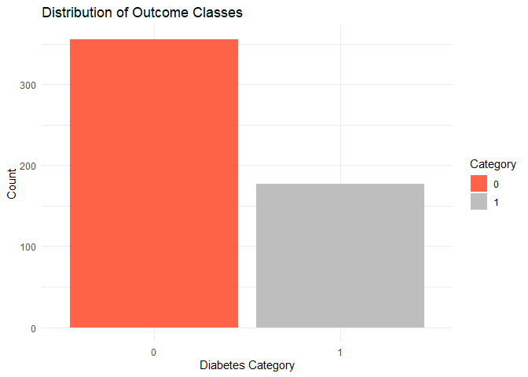

```r
# Visualize class distribution of Outcome
diabetis_cln$Outcome <- as.factor(diabetis_cln$Outcome)
ggplot(diabetis_cln, aes(x = Outcome, fill = Outcome)) +
  geom_bar() +
  scale_fill_manual(values = c("tomato", "grey")) +
  theme_minimal() +
  labs(
    title = "Distribution of Outcome Classes",
    x = "Diabetes Category",
    y = "Count",
    fill = "Category"
  )
```

### Train-Test Split

The classification dataset is split similarly to ensure fair evaluation. This mirrors the regression approach but targets class labels.

```r
set.seed(2025)
split_idx_clf <- caret::createDataPartition(diabetis_cln$Outcome, p = 0.75, list = FALSE)
train_clf <- diabetis_cln[split_idx_clf, ]
test_clf <- diabetis_cln[-split_idx_clf, ]
```

## Build Classification Decision Tree

```r
attach(diabetis_cln)
diabet_clf_tree <- rpart(
  Outcome~ .,
  data = train_clf,
  method = "class",
  control = rpart.control(minsplit = 20,   # need >=30 obs to try splitting
                          maxdepth = 8,    # limit tree depth to keep it readable
                          cp = 0.02)
)
```

## Visualize the Classification Tree

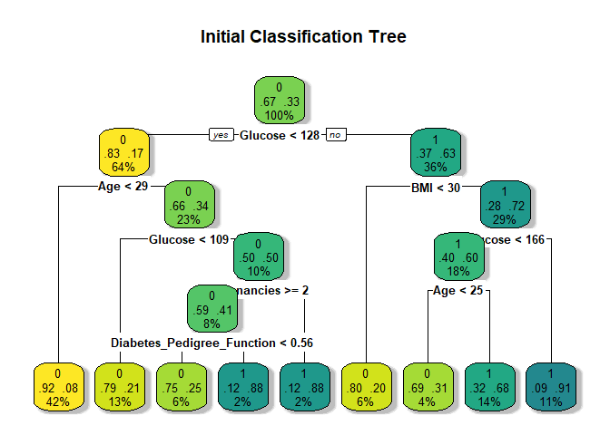

```r
rpart.plot(
  diabet_clf_tree,
  type =2,
  extra = 104,
  fallen.leaves = TRUE,
  box.palette = "YlGnBl",
  shadow.col = "gray",
  cex = 0.8,
  main = "Initial Classification Tree"
)
```

### Prune the Tree to Avoid Overfitting

Pruning a decision tree to avoid overfitting means simplifying a complex, fully grown tree by removing branches (nodes) that capture noise, not patterns, making the model generalize better to new data.

```r
# Find best cp and prune
best_cp_clf <- diabet_clf_tree$cptable[which.min(diabet_clf_tree$cptable[, "xerror"]), "CP"]
diabet_clf_tree_prune <- rpart::prune(diabet_clf_tree, cp = best_cp_clf)

# Check complexity parameters
printcp(diabet_clf_tree)
```

```
##
## Classification tree:
## rpart(formula = Outcome ~ ., data = train_clf, method = "class",
##     control = rpart.control(minsplit = 20, maxdepth = 8, cp = 0.02))
##
## Variables actually used in tree construction:
## [1] Age                        BMI
## [3] Diabetes_Pedigree_Function Glucose
## [5] Pregnancies
##
## Root node error: 133/400 = 0.3325
##
## n= 400
##
##         CP nsplit rel error  xerror     xstd
## 1 0.270677      0   1.00000 1.00000 0.070843
## 2 0.112782      1   0.72932 0.75940 0.065330
## 3 0.022556      2   0.61654 0.68421 0.063040
## 4 0.020000      8   0.48120 0.71429 0.063993
```

```r
rpart::prune(diabet_clf_tree, cp = best_cp_clf)
```

```
## n= 400
##
## node), split, n, loss, yval, (yprob)
##       * denotes terminal node
##
## 1) root 400 133 0 (0.6675000 0.3325000)
##   2) Glucose< 127.5 258  44 0 (0.8294574 0.1705426) *
##   3) Glucose>=127.5 142  53 1 (0.3732394 0.6267606)
##     6) BMI< 29.5 25   5 0 (0.8000000 0.2000000) *
##     7) BMI>=29.5 117  33 1 (0.2820513 0.7179487) *
```

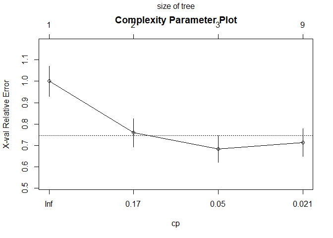

```r
plotcp(diabet_clf_tree, main = "Complexity Parameter Plot")
```

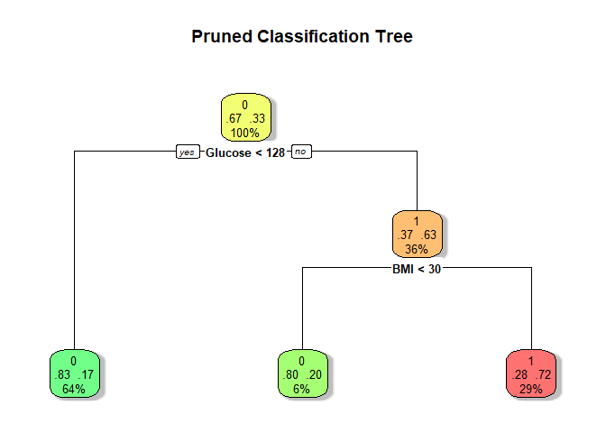

```r
# Plot pruned tree
rpart.plot(
  diabet_clf_tree_prune,
  type = 2,
  extra = 104,
  box.palette = "GnYlRd",
  fallen.leaves = TRUE,
  shadow.col = "gray",
  cex = 0.8,
  main = "Pruned Classification Tree"
)
```

### The complexity parameter (CP)

The Complexity Parameter (CP) in machine learning, especially for decision trees like CART, controls tree size by penalizing complexity; a larger CP leads to a smaller, simpler tree (pruned), while a smaller CP allows for a larger, more detailed tree, preventing overfitting by requiring significant improvement (relative error reduction) for new splits, often tuned via cross-validation to find the best balance for model performance.

### Predictions and Evaluation of the Performance

```r
# Predict class labels on test set
predicted_classes <- predict(diabet_clf_tree_prune, newdata = test_clf, type = "class")

# Confusion matrix
conf_matrix_clf <- confusionMatrix(predicted_classes, test_clf$Outcome)
conf_matrix_clf
```

```
## Confusion Matrix and Statistics
##
##           Reference
## Prediction  0  1
##          0 76 21
##          1 12 23
##
##                Accuracy : 0.75
##                  95% CI : (0.6672, 0.8212)
##     No Information Rate : 0.6667
##     P-Value [Acc > NIR] : 0.02426
##
##                   Kappa : 0.4072
##
##  Mcnemar's Test P-Value : 0.16373
##
##             Sensitivity : 0.8636
##             Specificity : 0.5227
##          Pos Pred Value : 0.7835
##          Neg Pred Value : 0.6571
##              Prevalence : 0.6667
##          Detection Rate : 0.5758
##    Detection Prevalence : 0.7348
##       Balanced Accuracy : 0.6932
##
##        'Positive' Class : 0
##
```

## Visualize Confusion Matrix

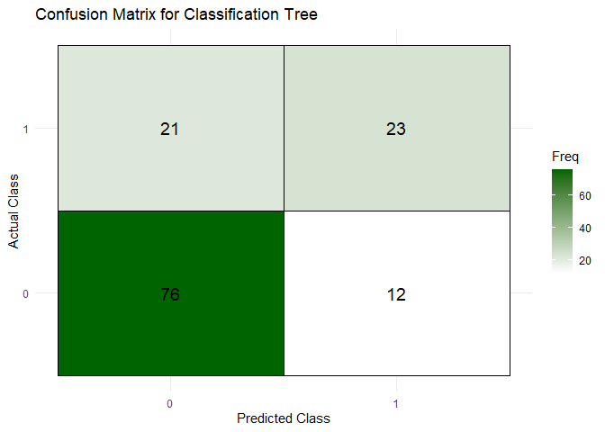

```r
cm_df_clf <- as.data.frame(conf_matrix_clf$table)

ggplot(cm_df_clf, aes(Prediction, Reference)) +
  geom_tile(aes(fill = Freq), color = "black") +
  geom_text(aes(label = Freq), size = 5) +
  scale_fill_gradient(low = "white", high = "darkgreen") +
  labs(
    title = "Confusion Matrix for Classification Tree",
    x = "Predicted Class",
    y = "Actual Class"
  ) +
  theme_minimal()
```

## Variable Importance

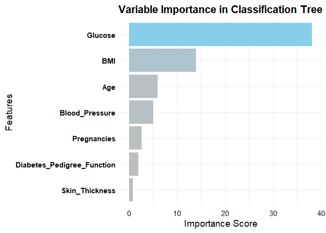

```r
# Get variable importance from the pruned classification tree
var_imp_clf <- diabet_clf_tree_prune$variable.importance

# Convert to a tidy data frame
imp_df <- data.frame(
  Feature = names(var_imp_clf),
  Importance = as.numeric(var_imp_clf)
)

# Sort and reorder for plotting
imp_df <- imp_df %>%
  arrange(Importance) %>%
  mutate(Feature = factor(Feature, levels = Feature))

# Plot with ggplot2
ggplot(imp_df, aes(x = Feature, y = Importance, fill = Importance)) +
  geom_col() +
  coord_flip() +
  scale_fill_gradient(low = "gray", high = "sky blue") +
  labs(
    title = "Variable Importance in Classification Tree",
    x = "Features",
    y = "Importance Score"
  ) +
  theme_minimal(base_size = 14) +
  theme(
    plot.title = element_text(hjust = 0.5, face = "bold"),
    axis.text.y = element_text(color = "black", face = "bold"),
    axis.text.x = element_text(color = "black"),
    legend.position = "none"
  )
```

### Exolanation

In classification tasks, feature importance is determined by how effectively each variable contributes to improving the purity of the node splits, using measures like Gini impurity or information gain. Here, the target variable Outcome is transformed into a categorical variable with two classes: Diabetic, Non- diabetic. Variables like Glucose and BMI still often rank highly because they help to distinguish between the diabetic and non-diabetic, which generally differ in health characteristics and physical attributes. However, in classification, other variables such as Age (Age),Blood_pressure, Pregnancies, Diabetes_Pedigree_Function, and Skin_Thickness may also gain importance if they help cleanly split one class from another.

### Classification Report

Precision, recall, and F1-scores are tabulated. These metrics highlight class-specific performance, crucial for imbalanced data.

```r
# Compute metrics
overall_accuracy <- conf_matrix_clf$overall["Accuracy"]
precision <- conf_matrix_clf$byClass["Pos Pred Value"]
recall <- conf_matrix_clf$byClass["Sensitivity"]
f1 <- 2 * (precision * recall) / (precision + recall)

# Create summary table
class_report <- data.frame(
  Metric = c("Accuracy", "Precision", "Recall", "F1-Score"),
  Value = c(overall_accuracy, precision, recall, f1)
)

# Display styled table
class_report %>%
  kbl(
    caption = "Classification Report: Binary Metrics",
    digits = 3,
    align = "c",
    format = "html"
  ) %>%
  kable_styling(
    bootstrap_options = c("striped", "hover", "condensed", "responsive"),
    full_width = FALSE,
    font_size = 14
  ) %>%
  column_spec(2, color = "white", background = "#4E79A7")
```

Classification Report: Binary Metrics

| Metric | Value |
| --- | --- |
| Accuracy | 0.750 |
| Precision | 0.784 |
| Recall | 0.864 |
| F1-Score | 0.822 |

# DECISION TREES ANALYSIS – CASE OF REGRESSION

## Dataset Description.

The **Salary** dataset contains information about the salaries of employees at a company. Each row represents a different employee, and the columns include information such as age, gender, education level, job title, years of experience, and salary.

### Variables Used:

[output not shown]

## Libraries and Setup

Key R libraries tools are loaded to streamline data processing, modeling, and evaluation.

```r
# Load necessary libraries
library(MASS)        # For Salary_Data dataset
library(rpart)       # For decision tree modeling
library(rpart.plot)  # For tree visualization
#library(caret)       # For train-test split and evaluation
library(dplyr)       # For data manipulation
library(ggplot2)     # For visualization
library(e1071)       # For model tuning
library(tidyverse)
library(kableExtra)
library(tidyr)
```

##Loading the Data

```r
Salary_Data= read.csv("Salary_Data.csv")
head(Salary_Data)
```

```
##   Age Gender Education.Level         Job.Title Years.of.Experience Salary
## 1  32   Male      Bachelor's Software Engineer                   5  90000
## 2  28 Female        Master's      Data Analyst                   3  65000
## 3  45   Male             PhD    Senior Manager                  15 150000
## 4  36 Female      Bachelor's   Sales Associate                   7  60000
## 5  52   Male        Master's          Director                  20 200000
## 6  29   Male      Bachelor's Marketing Analyst                   2  55000
```

## Data Inspection

```r
str(Salary_Data)
```

```
## 'data.frame':    375 obs. of  6 variables:
##  $ Age                : int  32 28 45 36 52 29 42 31 26 38 ...
##  $ Gender             : chr  "Male" "Female" "Male" "Female" ...
##  $ Education.Level    : chr  "Bachelor's" "Master's" "PhD" "Bachelor's" ...
##  $ Job.Title          : chr  "Software Engineer" "Data Analyst" "Senior Manager" "Sales Associate" ...
##  $ Years.of.Experience: num  5 3 15 7 20 2 12 4 1 10 ...
##  $ Salary             : int  90000 65000 150000 60000 200000 55000 120000 80000 45000 110000 ...
```

```r
summary(Salary_Data)
```

```
##       Age           Gender          Education.Level     Job.Title
##  Min.   :23.00   Length:375         Length:375         Length:375
##  1st Qu.:31.00   Class :character   Class :character   Class :character
##  Median :36.00   Mode  :character   Mode  :character   Mode  :character
##  Mean   :37.43
##  3rd Qu.:44.00
##  Max.   :53.00
##  NA's   :2
##  Years.of.Experience     Salary
##  Min.   : 0.00       Min.   :   350
##  1st Qu.: 4.00       1st Qu.: 55000
##  Median : 9.00       Median : 95000
##  Mean   :10.03       Mean   :100577
##  3rd Qu.:15.00       3rd Qu.:140000
##  Max.   :25.00       Max.   :250000
##  NA's   :2           NA's   :2
```

## DATA CLEANING

```r
# Check for missing values
sum(is.na(Salary_Data))
```

```
## [1] 6
```

```r
## Removing the missing values
Salary_Data <- na.omit(Salary_Data)
```

```r
# Check again for missing valuesd
sum(is.na(Salary_Data))
```

```
## [1] 0
```

No NA values in this dataset, so no imputation needed. This step is essential to avoid biases or errors during modeling.

```r
# Removing unnecessary columns
Salary_Data$Job.Title <- NULL
```

## Histograms

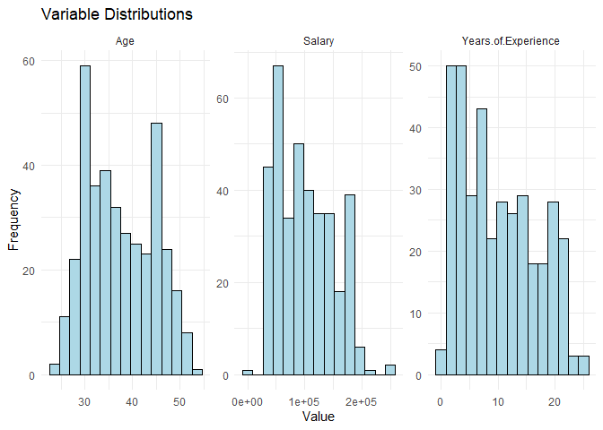

```r
# Select only numeric columns
numeric_data <- Salary_Data[, c("Age", "Years.of.Experience", "Salary")]

# Reshaping for ggplot
long_data <- tidyr::gather(numeric_data, key = "variable", value = "value")

# Plot histograms
ggplot(long_data, aes(x = value)) +
  geom_histogram(fill = "lightblue", color = "black", bins = 15) +
  facet_wrap(~variable, scales = "free") +
  labs(title = "Variable Distributions",
       x = "Value",
       y = "Frequency") +
  theme_minimal()
```

## Explanation The histograms of the Salary_Data housing dataset reveal the distributions of key numeric variables, providing insights into their skewness and potential impact on the model. For instance:

Age is roughly bell-shaped (like a normal distribution), but it appears slightly right-skewed (positively skewed). This means the tail of the distribution is longer on the right side, suggesting there are a few older individuals, but the vast majority of the data is concentrated on the younger side.

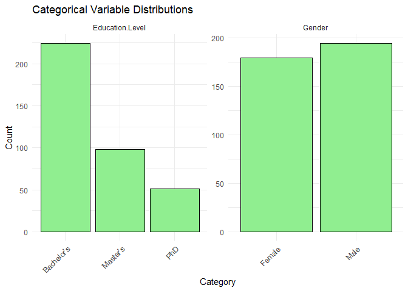

```r
# Select only categorical columns
categorical_data <- Salary_Data[, c("Gender", "Education.Level")]

# Reshape to long format
long_cat <- pivot_longer(categorical_data,
                         cols = everything(),
                         names_to = "variable",
                         values_to = "value")

# Plot bar charts for all categorical variables
ggplot(long_cat, aes(x = value)) +
  geom_bar(fill = "lightgreen", color = "black") +
  facet_wrap(~variable, scales = "free") +
  labs(title = "Categorical Variable Distributions",
       x = "Category",
       y = "Count") +
  theme_minimal() +
  theme(axis.text.x = element_text(angle = 45, hjust = 1))
```

# Explanation The distribution of education levels shows that most employees hold a Bachelor’s degree, with this group being the largest by a wide margin. Master’s degree holders form the second-largest group, though their numbers are noticeably lower. PhD holders make up the smallest portion of the dataset, representing only a small fraction of the total employees.

The gender distribution in the dataset is fairly balanced. The number of males is slightly higher, at around 195, while females make up about 180 of the entries. Overall, both genders are represented almost equally, with only a small difference between the two groups.

## Data Splitting (Training and Testing Sets)

```r
set.seed(123)
n <- nrow(Salary_Data)
train_indices <- sample(1:n, size = floor(0.75 * n))
train_data <- Salary_Data[train_indices, ]
test_data <- Salary_Data[-train_indices, ]
```

## Creation and fitting the initial unpruned decision tree model (with small cp value)

```r
initial_tree <- rpart(Salary ~ ., data = train_data, method = "anova",
                     control = rpart.control(cp = 0.0001, minsplit = 2))
```

## Plotting the initial unpruned tree

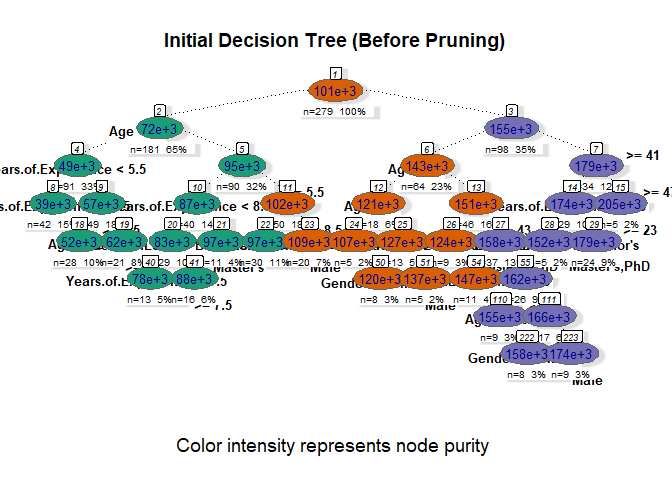

```r
# Create and fit a presentable initial decision tree (before pruning)
initial_tree <- rpart(Salary ~ ., data = train_data, method = "anova",
                     control = rpart.control(cp = 0.001, minsplit = 10, minbucket = 5))

# Plot the initial tree with enhanced visualization
rpart.plot(initial_tree,
           type = 4,
           extra = 101,
           under = TRUE,
           cex = 0.8,
           box.palette = c("#1B9E77", "#D95F02", "#7570B3"),  # Green-Orange-Purple palette
           nn = TRUE,                   # Show node numbers
           fallen.leaves = FALSE,       # Keep leaves at tree bottom
           shadow.col = "gray88",       # Subtle shadow effect
           branch.lty = 3,              # Dotted branch lines
           branch.lwd = 2,              # Slightly thicker branches
           main = "Initial Decision Tree (Before Pruning)",
           sub = "Color intensity represents node purity",
           col = "darkblue",           # Text color
           border.col = "gray40",       # Box border color
           roundint = FALSE)
```

## Explanation The initial unpruned decision tree is built using a very small complexity parameter (cp = 0.001), which allows the model to grow deep and capture detailed patterns in the training data. This results in a large, complex tree with many branches—some of which may fit noise rather than meaningful salary patterns.

Subsequent splits refine the predictions using variables such as Age, Education Level, and Gender, creating increasingly specific subgroups. These narrow branches lower training error but increase the risk of overfitting by modeling patterns that may not generalize beyond the training data.

The unpruned tree visualization shows dense and complex branching, which makes interpretation difficult. However, generating the full tree is an important first step, because it enables pruning later—removing weak or insignificant splits to produce a simpler and more reliable model. ## Create and fit the pruned decision tree model (with default cp)

```r
tree_fit <- rpart(Salary ~ ., data = train_data, method = "anova")
```

## Plot the pruned tree

```r
cat("\nFinal Pruned Decision Tree:\n")
```

```
##
## Final Pruned Decision Tree:
```

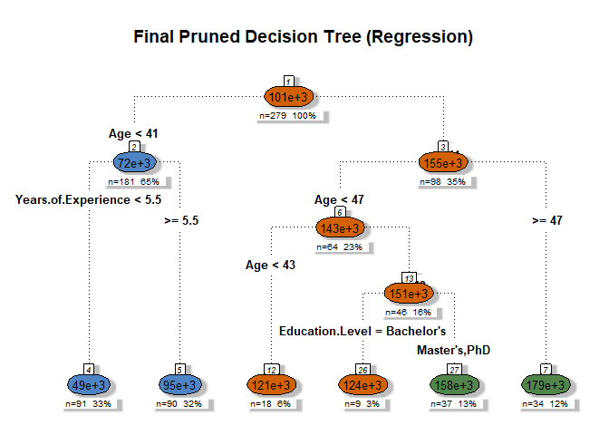

```r
rpart.plot(tree_fit, type = 4, extra = 101, under = TRUE, cex = 0.8,
           box.palette = c("#4E84C4", "#D16103", "#52854C"),  # Blue, Orange, Green
           nn = TRUE,  # Show node numbers
           shadow.col = "gray",  # Add subtle shadows
           main = "Final Pruned Decision Tree (Regression)",
           branch.lty = 3,  # Dotted branch lines
           roundint = FALSE)
```

The pruned tree keeps important splits such as Age < 41 and Years of Experience < 5.5, while removing less useful branches.

It has 6 terminal nodes, each representing a different salary range. Younger employees with little experience earn the lowest salaries, while older employees or mid-career employees with advanced degrees earn the highest.

## Make predictions on the testing data

```r
predictions <- predict(tree_fit, test_data)
```

## Calculate RMSE and R-squared

```r
rmse <- sqrt(mean((test_data$Salary - predictions)^2))
ss_res <- sum((test_data$Salary - predictions)^2)
ss_tot <- sum((test_data$Salary - mean(test_data$Salary))^2)
r_squared <- 1 - (ss_res / ss_tot)
```

## Display performance metrics

```r
cat("Model Performance:\n")
```

```
## Model Performance:
```

```r
cat("RMSE:", round(rmse, 3), "\n")
```

```
## RMSE: 16742.37
```

```r
cat("R-squared:", round(r_squared, 3), "\n")
```

```
## R-squared: 0.862
```

## Explanation

The Root Mean Squared Error (RMSE) is 16,742.37, which indicates that, on average, the model’s predicted salaries deviate from the actual salaries by about $16,742.

The R-squared value is 0.862, meaning the model explains 86.2% of the variance in employee salaries. In other words, the predictors—Age, Years of Experience, and Education Level—account for most of the differences in salary, showing strong predictive power.

However, the remaining 13.8% unexplained variance highlights limitations, potentially due to unmeasured factors like neighborhood amenities or more complex, nonlinear relationships that a single decision tree cannot fully capture. Together, these metrics confirm that the model is useful for identifying broad trends and making approximate valuations but may require enhancements—such as additional features, ensemble methods, or residual analysis—to improve precision for high-stakes applications. The balance between interpretability (from the tree structure) and accuracy (from the metrics) makes this model a practical tool for exploratory analysis.’

## CONCLUSION

The decision tree model effectively predicts employee salaries using Age, Years of Experience, and Education Level.

Age is the most influential factor, experience matters for younger employees, and higher education boosts salaries for mid-career staff.

The pruned tree provides an interpretable structure with clear salary ranges, while the model’s performance metrics—R-squared of 0.862 indicate strong predictive ability with moderate error. Overall, the model is reliable for understanding salary patterns and making informed predictions.